# Simutation

#### 2. 在不同variance下的power比較

$$L(\theta;X)=\prod^n_{i=1}f(x_i;\theta)=\big(\frac{1}{\sqrt{2\pi\sigma^2}}\big)^n e^{-\frac{\sum_{i=1}^{n}(x_i-\theta)^2}{2\sigma^2}}$$
$$l(\theta;X)=-\frac{n}{2}log2\pi\sigma^2-\frac{1}{2\sigma^2}\sum_{i=1}^{n}(x_i-\theta)^2$$
$$l'(\theta_0)=\frac{1}{\sigma^2}\sum_{i=1}^{n}(x_i-\theta_0)$$
$$I_1(\theta_0)=-E\bigg[\frac{\partial^2 logf(X;\theta)}{\partial \theta^2}\bigg]_{\big|\theta=\theta_0}=-E\bigg[\frac{1}{\sigma^2}\frac{\partial}{\partial\theta}(x-\theta)\bigg]=\frac{1}{\sigma^2}$$

[figure not shown]

```r
B<-200
n<-50
var1<-1
var2<-5
var3<-13
theta0<-2
theta.hat<-seq(1, 3, length.out =B)
RS1<-RS2<-RS3<-rep(NA,B)
power1<-power2<-power3<-rep(NA,B)    #p(W>qchisq(0.95,1) | H1)
for (j in 1:B){
  H1_mu<-theta.hat[j]
  for (i in 1:1000) {
    x1<-rnorm(n,mean=H1_mu,sd=sqrt(var1))
    x2<-rnorm(n,mean=H1_mu,sd=sqrt(var2))
    x3<-rnorm(n,mean=H1_mu,sd=sqrt(var3))
    V1<-n*I1/var1
    V2<-n*I1/var2
    V3<-n*I1/var3
    U1<-(sum(x1-theta0))/var1
    U2<-(sum(x2-theta0))/var2
    U3<-(sum(x3-theta0))/var3
    RS1[i]<-U1^2/V1
    RS2[i]<-U2^2/V2
    RS3[i]<-U3^2/V3
  }
  power1[j]<-mean(RS1>qchisq(0.95,1))
  power2[j]<-mean(RS2>qchisq(0.95,1))
  power3[j]<-mean(RS3>qchisq(0.95,1))
}
plot(smooth.spline(theta.hat,power1),type="l",col=2,main="Power Curve",ylim=c(0,1),xlab=expression(theta),ylab="Power")
lines(smooth.spline(theta.hat,power2),type="l",col=3)
lines(smooth.spline(theta.hat,power3),type="l",col=4)
legend("topright",c("Simulation -- n=10","Simulation -- n=50","Simulation -- n=200"),lty = rep(1,3),col = c(2,3,4),cex = 0.8)
```

```r
score_power_mu_var1<-smooth.spline(theta.hat,power1)
score_power_mu_var2<-smooth.spline(theta.hat,power2)
score_power_mu_var3<-smooth.spline(theta.hat,power3)
```

$$N(1,\theta)$$

考慮$n=200$個random sample,$X_1,X_2,...,X_{200}\sim N(1,\theta)$, $H_0：\theta=0.81$

```r
set.seed(1234)
n <- 200
mu <- 1
sigma <- 0.81 #sigma=sqrt(sigma)
x <- rnorm(n,mean=mu,sd=sqrt(sigma))
mean(var(x))
```

```
## [1] 0.8438252
```

我們得到最大概似估計量為

$$\hat\theta= \frac{1}{n}\sum_{i=1}^{200} (x_i-1)^2 \approx 0.843$$

```r
set.seed(1234)
B<-1000
Lf<-function(x,theta) prod( dnorm(x,mean=mu,sd=sqrt(theta)) ) #likelihood function
theta.hat<-seq(0.5, 1.2, length.out = B)

L<-l<-c()
for (i in 1:B){
  #x<-rnorm(n,mean=0,sd=theta)
  L[i]<-Lf(x,theta.hat[i])
  l[i]<-log(L[i])
}
#compare simlution MLE and theretical MLE
theta_MLE=(theta.hat[which.max(l)])
theta_MLE;mean(var(x))*(n-1)/n
```

```
## [1] 0.8426426
```

```
## [1] 0.839606
```

### 以下將以模擬，證明下面兩式

$$I_1(\theta)=E\bigg[\bigg(\frac{\partial logf(X;\theta)}{\partial \theta}\bigg)^2\bigg]=-E\bigg[\frac{\partial^2 logf(X;\theta)}{\partial \theta^2}\bigg]$$
$$E\bigg[\frac{\partial logf(X;\theta)}{\partial \theta}\bigg]=0$$

我們從$n=80$個樣本中取出一個樣本$X_1$，並求其$logf(X;\theta)$，由於每個樣本中有$R=200$個觀測值$x_1,...,x_{200}$，每條線代表固定$x$的情況下，不同$\theta$的$logf(X;\theta)$構成的線，因此會有200條線

$$logf(x;\theta)=-\frac{1}{2}log(2\pi\theta)-\frac{(x-1)^2}{2\theta}$$

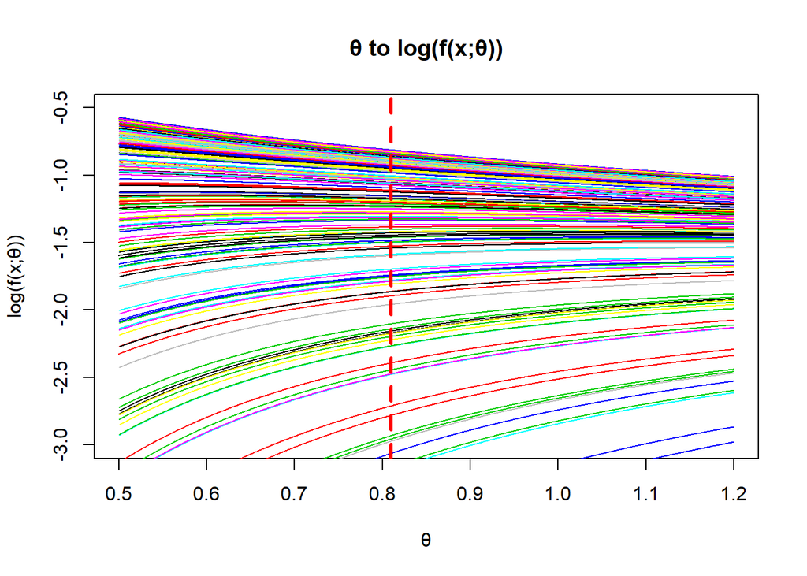

```r
set.seed(1234)
n<-80  # num of samples
R<-200  # simulation times
B<-5000  # num of possible theta
xx<-seq(0.5, 1.2, length.out = B)
fy<-matrix(NA,R,B)
rnormf<-rnorm(R,mean=mu,sd=sqrt(sigma))  # one sample (X_1) with R observations
for(j in 1:R){
  for(i in 1:B){
    fy[j,i]<-dnorm(x=rnormf[j],mean=mu,sd=sqrt(xx[i]),log = TRUE)
  }
  if(j==1){
    plot(xx,fy[1,],xlim=c(0.5,1.2),ylim=c(-3,-0.5),type = 'l',xlab='θ',ylab = 'log(f(x;θ))',main='θ to log(f(x;θ))')
  }else{
    lines(xx,fy[j,],col=j)
  }
}
abline(v=sigma,col=2,lty=2,lwd=3)
text(sigma,-10.2, labels=sigma, col=1,cex=1.3, font=2,pos=3)
```

將$logf(x;\theta)$對$\theta$做一次偏微分
$$logf'(x;\theta)=-\frac{1}{2\theta}+\frac{(x-1)^2}{2\theta^2}$$

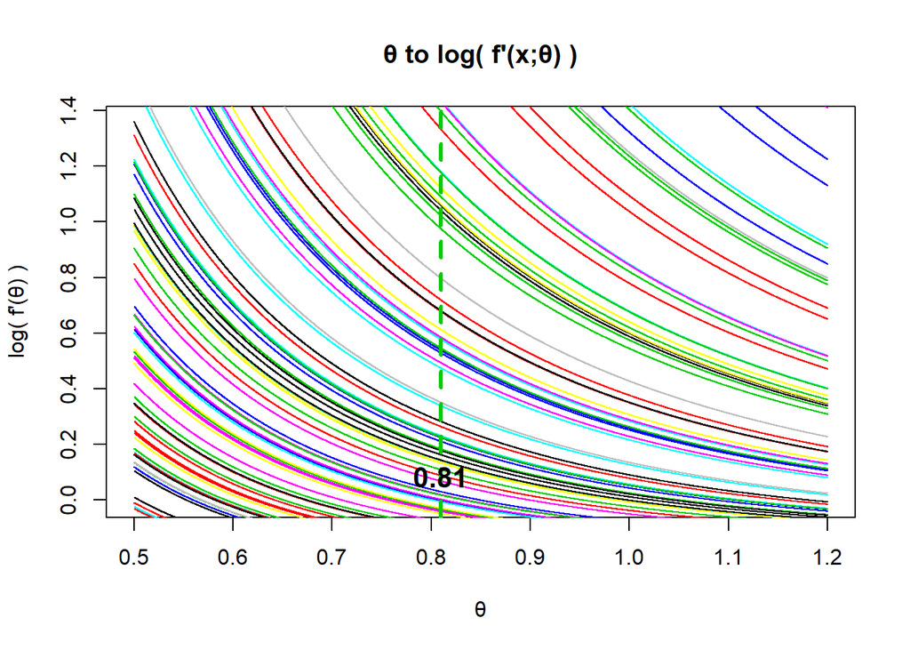

```r
set.seed(1234)
fydiff<-matrix(NA,R,B)
sigma2<-c(0.5,sigma,1.2)
fydiff2<-c()
for(j in 1:R){
  spl <- smooth.spline(fy[j,] ~ xx)
  for(i in 1:B){
    fydiff[j,i] <- predict(spl, x=xx[i], deriv=1)$y
  }
  if(j==1){
    plot(xx,fydiff[1,],type='l',xlab='θ',ylab = 'log( f\'(θ) )',main='θ to log( f\'(x;θ) )')
  }else{
    lines(xx,fydiff[j,],col=j)
  }
  spl2 <- smooth.spline(fydiff[j,] ~ xx)
  fydiff2[j] <- predict(spl2, x=xx[i], deriv=1)$y
}
abline(v=sigma,col=3,lty=2,lwd=3)
text(sigma,0, labels=sigma, col=1,cex=1.3, font=2,pos=3)
```

```r
mean(fydiff);0
```

```
## [1] 0.0766295
```

```
## [1] 0
```

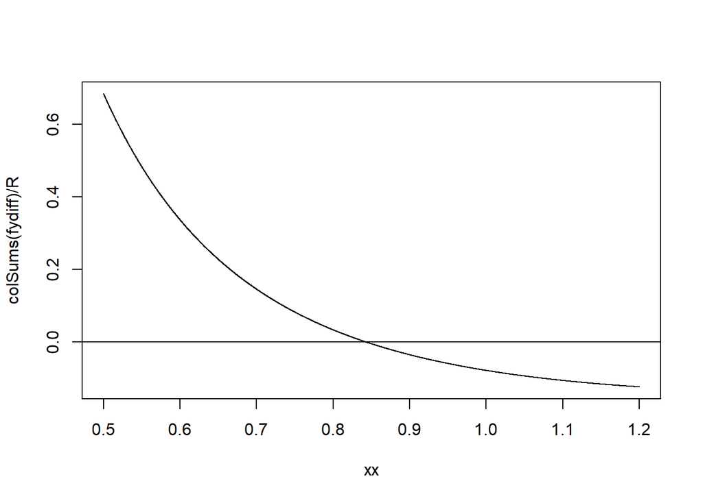

```r
#mean(((rowSums(fydiff)/B)^2)^2);mean(fydiff2^2);9
plot(xx,colSums(fydiff)/R,type='l')
abline(h=0)
```

```r
spl<-spline(colSums(fydiff)/R~xx)
spl$x[which.min(abs(spl$y))];theta_MLE
```

```
## [1] 0.8423228
```

```
## [1] 0.8426426
```

針對不同的$\theta_0,\theta_1,....,\theta_n$證明
$$E\bigg[\frac{\partial}{\partial\theta}logf(\theta)_{|\theta=\theta_0}\bigg]=0$$

```r
set.seed(1234)
fydifftheta<-matrix(NA,length(sigma2),R)
for(k in 1:length(sigma2)){
  for(j in 1:R){
    spl <- smooth.spline(fy[j,] ~ xx)
    fydifftheta[k,j]<-predict(spl, x=sigma2[k], deriv=1)$y
  }
}
sigma2[1];mean(fydifftheta[1,])
```

```
## [1] 0.5
```

```
## [1] 0.6846165
```

```r
sigma2[2];mean(fydifftheta[2,])
```

```
## [1] 0.81
```

```
## [1] 0.02462147
```

```r
sigma2[3];mean(fydifftheta[3,])
```

```
## [1] 1.2
```

```
## [1] -0.1241985
```

$$L(x;\theta)=\prod^n_{i=1}f(x;\theta)=(2\pi\theta)^\frac{-n}{2}exp\lbrace \frac{-\sum_{i=1}^{n}(x_i-1)^2}{2\theta} \rbrace$$
$$l=logL(x;\theta)=-\frac{n}{2}log(2\pi\theta)-\frac{\sum_{i=1}^{n}(x_i-1)^2}{2\theta}$$
$$\frac{\partial l}{\partial \theta}=-\frac{n}{2\theta}+\frac{\sum_{i=1}^{n}(x_i-1)^2}{2\theta^2}$$

藉由n個樣本，證明
$$\hat\theta_{MLE}=\frac{1}{n} \sum_{i=1}^{n} (x_i-1)^2$$

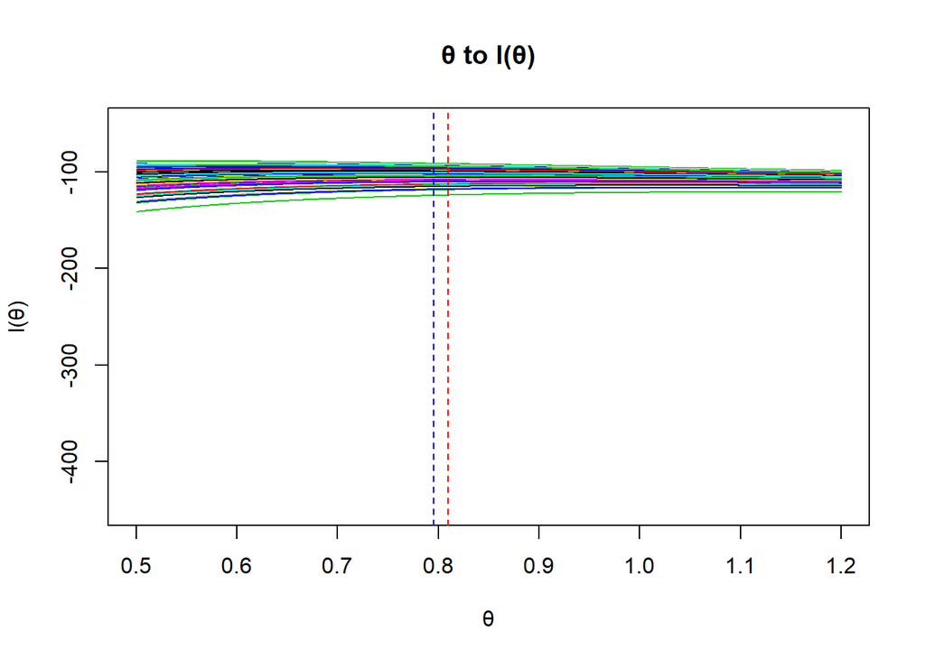

```r
set.seed(1234)
n<-80  # num of samples
R<-100  # simulation times
B<-5000  # num of possible theta
xx<-seq(0.5, 1.2, length.out = B)
logLf<-function(x,theta) log(prod( dnorm(x,mean=mu,sd=theta) ))
rnormdf<-matrix(rnorm(n*R,mean=mu,sd=sqrt(sigma)), n, R)
xa<-rnormdf[,1]
ly<-matrix(NA,R,B)
theta_MLE<-c()
for(j in 1:R){
  xa<-rnormdf[,j]
  for(i in 1:B){
    ly[j,i]<-logLf(x=xa,theta=sqrt(xx[i]))
  }
  if(j==1){
    plot(xx,ly[1,],xlim=c(0.5,1.2),ylim=c(-450,-50),type = 'l',xlab='θ',ylab = 'l(θ)',main='θ to l(θ)')
  }else{
    lines(xx,ly[j,],col=j)
  }
  theta_MLE[j]<-xx[which.max(ly[j,])]
}
abline(v=mean(theta_MLE),col="blue",lty=2)
abline(v=sigma,col=2,lty=2)
```

```r
mean(theta_MLE);var(theta_MLE)
```

```
## [1] 0.7955529
```

```
## [1] 0.01606035
```

```r
mean(theta_MLE*n/(n-1))#unbiased estimator
```

```
## [1] 0.8056232
```

$$I_1(\theta)=-E\bigg[\frac{\partial^2 logf(X;\theta)}{\partial \theta^2}\bigg]=-E\bigg[\frac{\partial}{\partial\theta}\bigg(-\frac{1}{2\theta}+\frac{(x-1)^2}{2\theta^2}\bigg)\bigg]=\frac{1}{2\theta^2}\approx0.7621$$

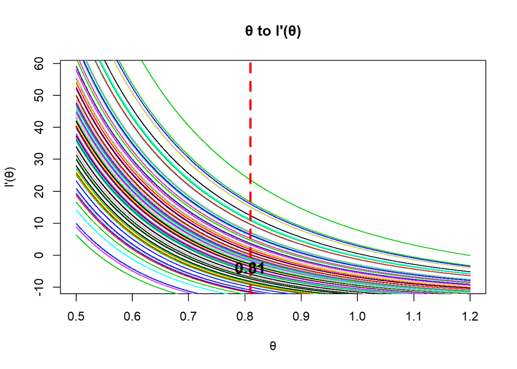

```r
lydiff<-matrix(NA,R,B)
lydiff2<-c()
for(j in 1:R){
  spl <- smooth.spline(ly[j,] ~ xx)
  for(i in 1:B){
    lydiff[j,i] <- predict(spl, x=xx[i], deriv=1)$y
  }
  if(j==1){
    plot(xx,lydiff[1,],type='l',xlab='θ',ylab = 'l\'(θ)',main='θ to l\'(θ)')
  }else{
    lines(xx,lydiff[j,],col=j)
  }
  spl2 <- smooth.spline(lydiff[j,] ~ xx)
  lydiff2[j] <- predict(spl2, x=xx[i], deriv=1)$y
}
abline(v=sigma,col=2,lty=2,lwd=3)
text(sigma,-8, labels=sigma, col=1,cex=1.3, font=2,pos=3)
```

```r
lydiffi <- rowSums(lydiff)/B
mean(lydiffi);0
```

```
## [1] 3.012914
```

```
## [1] 0
```

```r
mean(lydiffi^2);var(lydiffi) #76.21   #n*-mean(fydiff2)  #In n/(2*sigma^2)-1/(sigma^3)*mean((xx-1)^2)
```

```
## [1] 79.75324
```

```
## [1] 71.38949
```

```r
In<-var(lydiffi)
#I1<-mean(fydiff2)*-1 #I1(θ)
#In<-n*I1
#In
```

### 檢定

根據前面的推導過程，我們用前面的資料，證明$\chi^2_R \approx \chi^2_1$

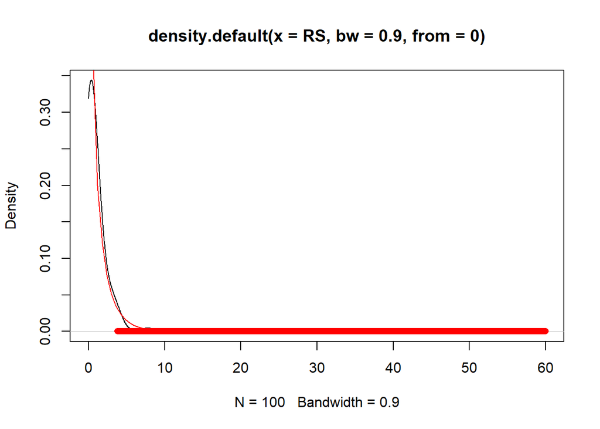

```r
lydifftheta<-c()
for(j in 1:R){
  spl <- smooth.spline(ly[j,] ~ xx)
  lydifftheta[j]<-predict(spl, x=sigma, deriv=1)$y
}

U<-lydifftheta
V<-var(lydiffi)  #In
RS<-U^2/V
plot(density(RS,from=0,bw=0.9),xlim=c(0,60))
curve(dchisq(x,df=1),add=T,col=2)

alpha<-0.05
#abline(h=alpha,col=2,lwd=2)
RR<-seq(qchisq(1-alpha,1),60,0.001)
points(RR,rep(0,length(RR)), col=2, pch=16, cex=1)
```

### 檢定力Power of test

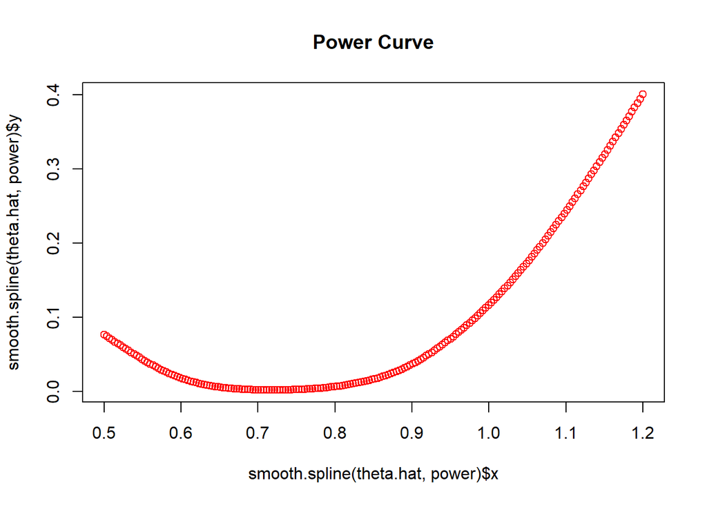

```r
B<-200
n<-50
sigma<-0.81
theta.hat<-seq(0.5, 1.2, length.out =B)
RS<-rep(NA,B)
power<-rep(NA,B)    #p(W>qchisq(0.95,1) | H1)
for (j in 1:B){
  H1_sigma<-theta.hat[j]
  for (i in 1:B) {
    x<-rnorm(n,mean=mu,sd=sqrt(H1_sigma))
    V<-In
    U<-sum((-1/(2*sigma))+((x-1)^2)/(2*sigma^2))
    RS[i]<-U^2/In
  }
  power[j]<-mean(RS>qchisq(0.95,1))
}
plot(smooth.spline(theta.hat,power),col=2,main="Power Curve")
```

### 1. 在不同樣本數的Power比較

[figure not shown]

```r
#不同樣本數
B<-200
n1<-30
n2<-50
n3<-200

sigma<-0.81
I1<-1/2/sigma^2
theta.hat<-seq(0.5, 1.2, length.out =B)
RS1<-RS2<-RS3<-rep(NA,B)
power1<-power2<-power3<-rep(NA,B)    #p(W>qchisq(0.95,1) | H1)
for (j in 1:B){
  H1_sigma<-theta.hat[j]
  for (i in 1:1000) {
    x1<-rnorm(n1,mean=mu,sd=sqrt(H1_sigma))
    x2<-rnorm(n2,mean=mu,sd=sqrt(H1_sigma))
    x3<-rnorm(n3,mean=mu,sd=sqrt(H1_sigma))
    V1<-n1*I1
    V2<-n2*I1
    V3<-n3*I1
    U1<--n1/(2*sigma)+sum((x1-1)^2)/(2*sigma^2)
    U2<--n2/(2*sigma)+sum((x2-1)^2)/(2*sigma^2)
    U3<--n3/(2*sigma)+sum((x3-1)^2)/(2*sigma^2)
    RS1[i]<-U1^2/V1
    RS2[i]<-U2^2/V2
    RS3[i]<-U3^2/V3
  }
  power1[j]<-mean(RS1>qchisq(0.95,1))
  power2[j]<-mean(RS2>qchisq(0.95,1))
  power3[j]<-mean(RS3>qchisq(0.95,1))
}
plot(smooth.spline(theta.hat,power1),type="l",col=2,main="Power Curve",ylim=c(0,1),xlab=expression(theta),ylab="Power")
lines(smooth.spline(theta.hat,power2),type="l",col=3)
lines(smooth.spline(theta.hat,power3),type="l",col=4)
legend("topright",c("Simulation -- n=10","Simulation -- n=50","Simulation -- n=200"),lty = rep(1,3),col = c(2,3,4),cex = 0.8)
```

```r
score_power_var_n1<-smooth.spline(theta.hat,power1)
score_power_var_n2<-smooth.spline(theta.hat,power2)
score_power_var_n3<-smooth.spline(theta.hat,power3)
```

### 2.在不同平均數的Power比較

$$I_1(\theta_0)=-E\bigg[\frac{\partial^2 logf(X;\theta)}{\partial \theta^2}\bigg]_{\big|\theta=\theta_0}=-E\bigg[\bigg(\frac{1}{2\theta_0^2}-\frac{(x-1)^2}{\theta_0^3}\bigg)\bigg]=\frac{1}{2\theta_0^2}+\frac{(\mu-1)^2}{\theta_0^3}$$

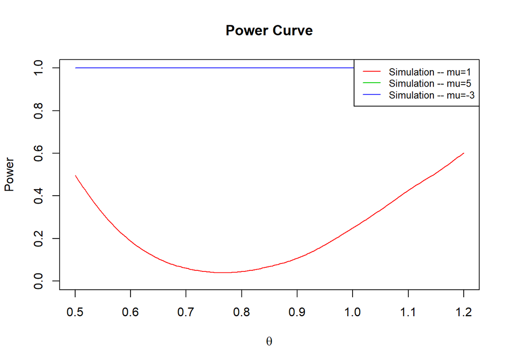

```r
#不同平均數
B<-200
n<-50
mu1<-1
mu2<-5
mu3<--3
theta.hat<-seq(0.5, 1.2, length.out =B)
RS1<-RS2<-RS3<-rep(NA,B)
power1<-power2<-power3<-rep(NA,B)    #p(W>qchisq(0.95,1) | H1)
for (j in 1:B){
  H1_sigma<-theta.hat[j]
  for (i in 1:1000) {
    x1<-rnorm(n,mean=mu1,sd=sqrt(H1_sigma))
    x2<-rnorm(n,mean=mu2,sd=sqrt(H1_sigma))
    x3<-rnorm(n,mean=mu3,sd=sqrt(H1_sigma))
    I1_1<-1/(2*sigma^2)+(mu1-1)^2/(sigma^3)
    I1_2<-1/(2*sigma^2)+(mu2-1)^2/(sigma^3)
    I1_3<-1/(2*sigma^2)+(mu3-1)^2/(sigma^3)
    V1<-n*I1_1
    V2<-n*I1_2
    V3<-n*I1_3
    U1<--n/(2*sigma)+sum((x1-1)^2)/(2*sigma^2)
    U2<--n/(2*sigma)+sum((x2-1)^2)/(2*sigma^2)
    U3<--n/(2*sigma)+sum((x3-1)^2)/(2*sigma^2)
    RS1[i]<-U1^2/V1
    RS2[i]<-U2^2/V2
    RS3[i]<-U3^2/V3
  }
  power1[j]<-mean(RS1>qchisq(0.95,1))
  power2[j]<-mean(RS2>qchisq(0.95,1))
  power3[j]<-mean(RS3>qchisq(0.95,1))
}
plot(smooth.spline(theta.hat,power1),type="l",ylim=c(0,1),col=2,main="Power Curve",xlab=expression(theta),ylab="Power")
lines(smooth.spline(theta.hat,power2),type="l",col=3)
lines(smooth.spline(theta.hat,power3),type="l",col=4)
legend("topright",c("Simulation -- mu=1","Simulation -- mu=5","Simulation -- mu=-3"),lty = rep(1,3),col = c(2,3,4),cex = 0.8)
```

```r
score_power_var_mean1<-smooth.spline(theta.hat,power1)
score_power_var_mean2<-smooth.spline(theta.hat,power2)
score_power_var_mean3<-smooth.spline(theta.hat,power3)
```

## Exponential distribution exp(rate)

$Exp(\theta)$

### 我們將先證明

$$\hat\theta_{MLE}=\frac{1}{\bar{X}}$$

我們考慮$n=200$個random sample, $X_1,X_2,...,X_{200}\sim Exp(rate)$

```r
# Exp(theta)
# Set the parameter
set.seed(123)
n = 200
rate = 2
rate1 = 1
rate2 = 3.5
X = rexp(n,rate=rate) # X1,...,Xn
```

此時我們可以得到最大概似估計量為樣本平均$\hat\theta=\frac{1}{\bar{X}}\approx1.986$

```r
# Set Likelihood function
B = 10000
Lf = function(x,r) prod( dexp(x,rate=r) )
theta.hat = seq(rate1,rate2,length.out = B)

#Find the MLE
L = l = c()
for (i in 1:B){
  #x<-rnorm(n,mean=mean,sd=1)
  L[i] = Lf(X,theta.hat[i])
  l[i] = log(L[i])
}
# compare simlution MLE and theretical MLE
theta_MLE = theta.hat[which.max(l)]
theta_MLE ; 1/mean(X)
```

```
## [1] 1.985599
```

```
## [1] 1.985638
```

### 以下將以模擬，證明下面兩式

$$I_1(\theta)=E\bigg[\bigg(\frac{\partial logf(X;\theta)}{\partial \theta}\bigg)^2\bigg]=-E\bigg[\frac{\partial^2 logf(X;\theta)}{\partial \theta^2}\bigg]$$
$$E\bigg[\frac{\partial logf(X;\theta)}{\partial \theta}\bigg]=0$$

我們從$n=80$個樣本中取出一個樣本$X_1$，並求其$logf(X;\theta)$，由於每個樣本中有$R=200$個觀測值$x_1,...,x_{200}$，每條線代表固定$x$的情況下，不同$\theta$的$logf(X;\theta)$構成的線，因此會有200條線
$$logf(x;\theta)=log\theta-\theta x$$

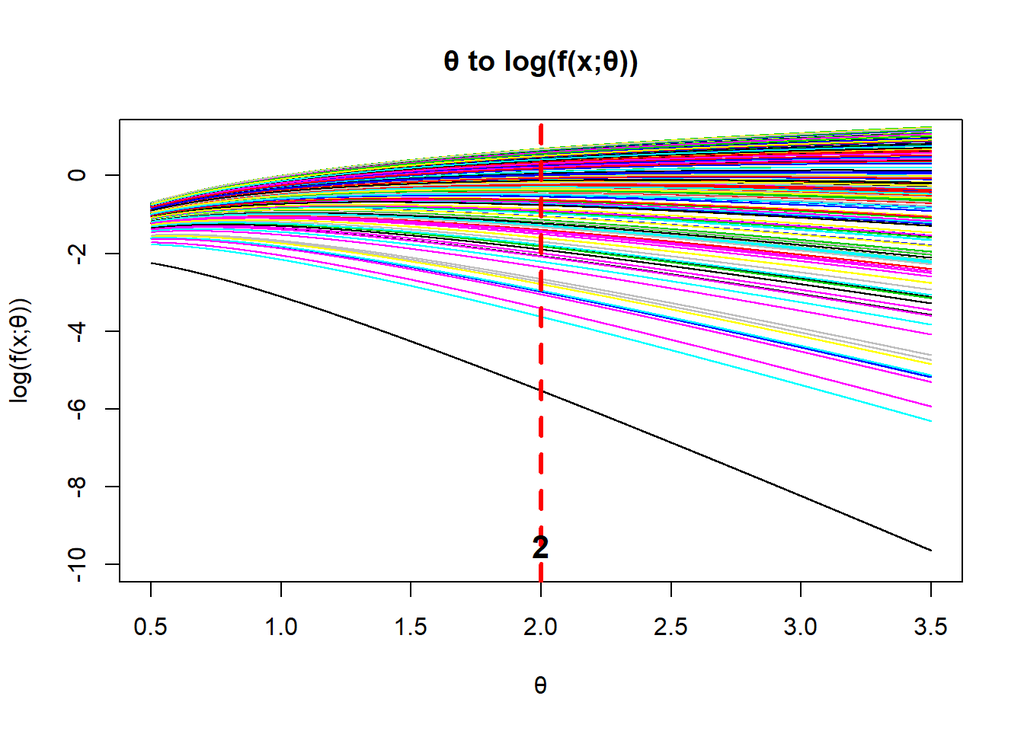

```r
rate1 = 0.5
rate2 = 3.5
set.seed(1234)
n<-80  # num of samples
R<-200  # simulation times
B<-10000  # num of possible theta
xx<-seq(rate1, rate2, length.out = B)
fy<-matrix(NA,R,B)
rexpdf<-rexp(R,rate=rate)  # one sample (X_1) with R observations
for(j in 1:R){
  for(i in 1:B){
    fy[j,i]<-dexp(x=rexpdf[j],rate=xx[i],log = TRUE)
  }
  if(j==1){
    plot(xx,fy[1,],xlim=c(rate1,rate2),ylim=c(-10,1),type = 'l',xlab='θ',ylab = 'log(f(x;θ))',main='θ to log(f(x;θ))')
  }else{
    lines(xx,fy[j,],col=j)
  }
}
abline(v=rate,col=2,lty=2,lwd=3)
text(rate,-10.2, labels=rate, col=1,cex=1.3, font=2,pos=3)
```

我們將$logf(X;\theta)$ 對$\theta$做一次偏微分

$$\frac{\partial}{\partial\theta}logf(\theta)=\frac{1}{\theta}-x$$

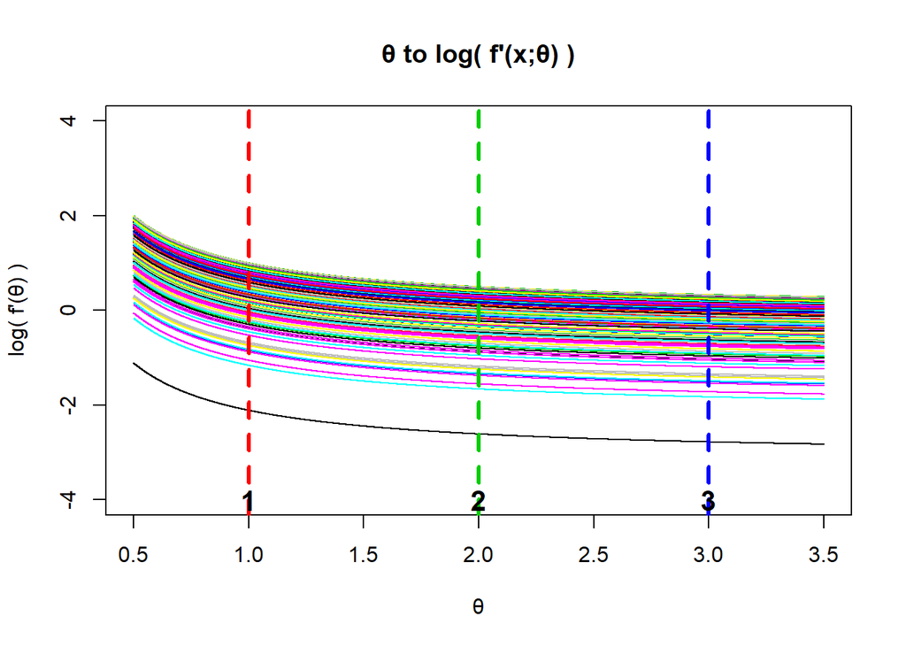

```r
set.seed(6053)

fydiff<-matrix(NA,R,B)
fydiff2<-c()
theta2<-c(rate-1,rate,rate+1)
#p<-matrix(NA,R,B)
p<-c()
p2<-c()
for(j in 1:R){
  #s1 <- smooth.spline(fy[j,] ~ xx)
  spl <- smooth.spline(fy[j,] ~ xx)
  p[j]<-predict(spl,x=rate,derive=1)$y
  for(i in 1:B){
    fydiff[j,i] <- predict(spl, x=xx[i], deriv=1)$y
  }
  if(j==1){
    plot(xx,fydiff[1,],ylim=c(-4,4),type='l',xlab='θ',ylab = 'log( f\'(θ) )',main='θ to log( f\'(x;θ) )')
  }else{
    lines(xx,fydiff[j,],col=j)
  }
  spl2 <- smooth.spline(fydiff[j,] ~ xx)
  fydiff2[j] <- predict(spl2, x=xx[i], deriv=1)$y
  #s2 <-smooth.spline(p[j,]~rate)
  p2[j]<- predict(spl2,x=rate,deriv=1)$y
}
abline(v=theta2,col=c(2,3,4),lty=2,lwd=3)
text(theta2,-4.5, labels=theta2, col=1,cex=1.3, font=2,pos=3)
```

$$E\bigg[\frac{\partial logf(X;\theta)}{\partial \theta}\bigg]=0$$

```r
mean(fydiff)
```

```
## [1] 0.1464059
```

```r
mean(p)
```

```
## [1] -0.3114132
```

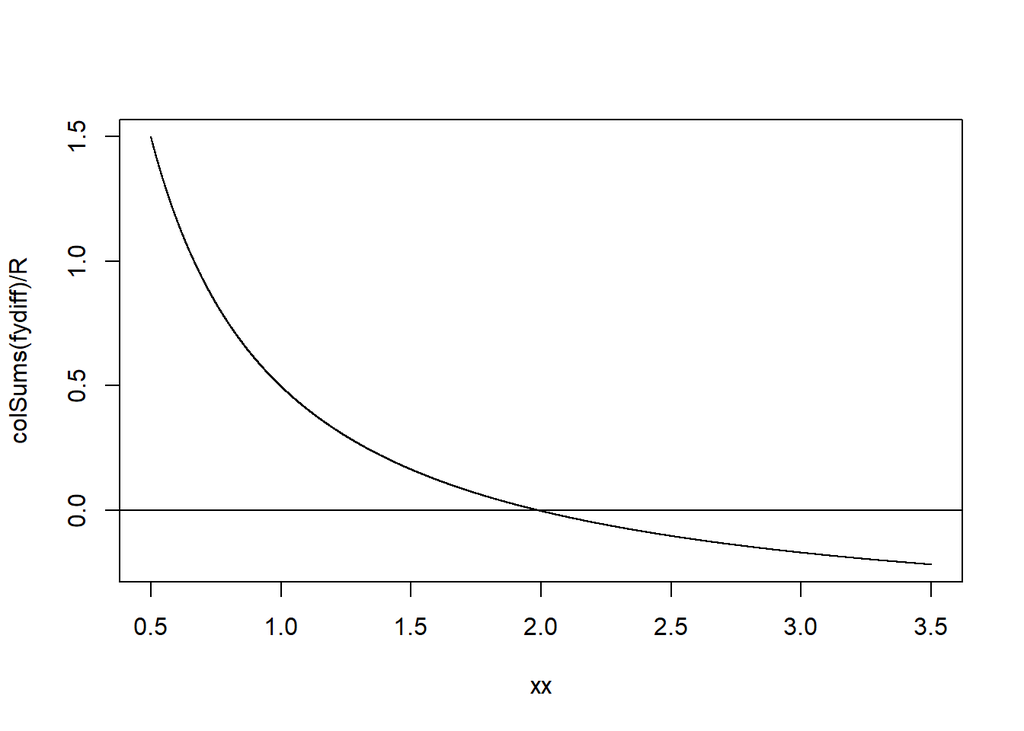

```r
plot(xx,colSums(fydiff)/R,type='l')
abline(h=0)
```

```r
spl<-spline(colSums(fydiff)/R~xx)
spl$x[which.min(abs(spl$y))]
```

```
## [1] 1.99095
```

$$I_1(\theta)=E\bigg[\bigg(\frac{\partial logf(X;\theta)}{\partial \theta}\bigg)^2\bigg]=-E\bigg[\frac{\partial^2 logf(X;\theta)}{\partial \theta^2}\bigg]=-E\bigg[\frac{\partial}{\partial\theta}(\frac{1}{\theta}-x)\bigg]=\frac{1}{\theta^2}$$

```r
mean((rowSums(fydiff)/B)^2);1/(2^2)
```

```
## [1] 0.2612964
```

```
## [1] 0.25
```

```r
#mean(fydiff2)*-1;1

#mean(p^2)
mean(p2)*-1 ; 1/rate^2
```

```
## [1] 0.25
```

```
## [1] 0.25
```

### 以下將針對不同的

$\theta_0,\theta_1,\theta_2,...,\theta_i,...$證明
$$E\bigg[\frac{\partial}{\partial\theta}logf(\theta)_{|\theta=\theta_0}\bigg]=0$$
我們取$θ$範圍內的三個值，包含$θ_0=2$，求出這三個$θ$下的$\frac{\partial}{\partial\theta}logf(\theta)$之期望值

```r
set.seed(1234)
fydifftheta<-matrix(NA,length(theta2),R)
for(k in 1:length(theta2)){
  for(j in 1:R){
    spl <- smooth.spline(fy[j,] ~ xx)
    fydifftheta[k,j]<-predict(spl, x=theta2[k], deriv=1)$y
  }
}
theta2[1];mean(fydifftheta[1,])
```

```
## [1] 1
```

```
## [1] 0.4977198
```

```r
theta2[2];mean(fydifftheta[2,])
```

```
## [1] 2
```

```
## [1] -0.002280199
```

```r
theta2[3];mean(fydifftheta[3,])
```

```
## [1] 3
```

```
## [1] -0.1689469
```

### 檢定

透過n個樣本，再次證明
$$\hat\theta_{MLE}=\frac{1}{\bar{X}}$$

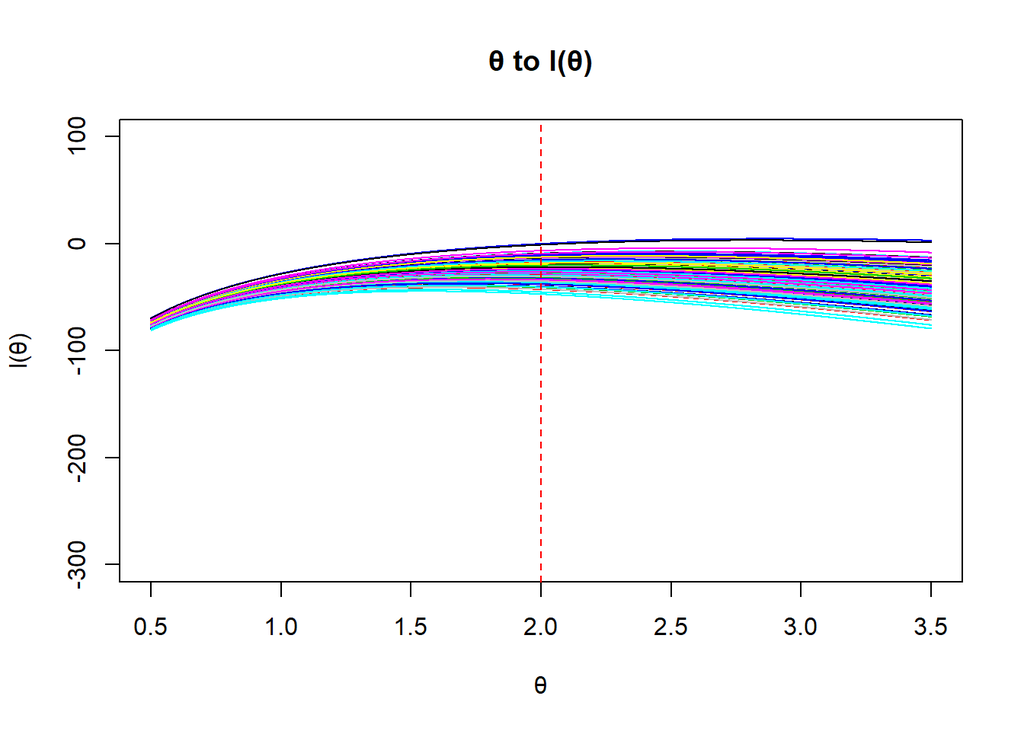

```r
set.seed(12345)
logLf<-function(x,r) log(prod( dexp(x,rate=r) ))
rexpdf<-matrix(rexp(n*R,rate=rate), n, R)
xa<-rexpdf[,1]
ly<-matrix(NA,R,B)
theta_MLE<-c()
for(j in 1:R){
  xa<-rexpdf[,j]
  for(i in 1:B){
    ly[j,i]<-logLf(x=xa,r=xx[i])
  }
  if(j==1){
    plot(xx,ly[1,],xlim=c(rate1,rate2),ylim=c(-300,100),type = 'l',xlab='θ',ylab = 'l(θ)',main='θ to l(θ)')
  }else{
    lines(xx,ly[j,],col=j)
  }
  theta_MLE[j]<-xx[which.max(ly[j,])]
}
abline(v=rate,col=2,lty=2)
```

```r
mean(theta_MLE);1/mean(rexpdf)  #theta_MLE=1/xbar
```

```
## [1] 2.02291
```

```
## [1] 1.999977
```

```r
var(theta_MLE);1/(mean(rexpdf)^2)/n #variance of xbar
```

```
## [1] 0.04898779
```

```
## [1] 0.04999886
```

$$E\bigg[\frac{\partial}{\partial \theta} logL(X;\theta)\bigg]=E\bigg[\frac{\partial }{\partial \theta}\sum^{n}_{i=1} logf(x_i;\theta)\bigg]=\sum^{n}_{i=1}E\bigg[\frac{\partial }{\partial \theta} logf(x_i;\theta)\bigg]=0$$

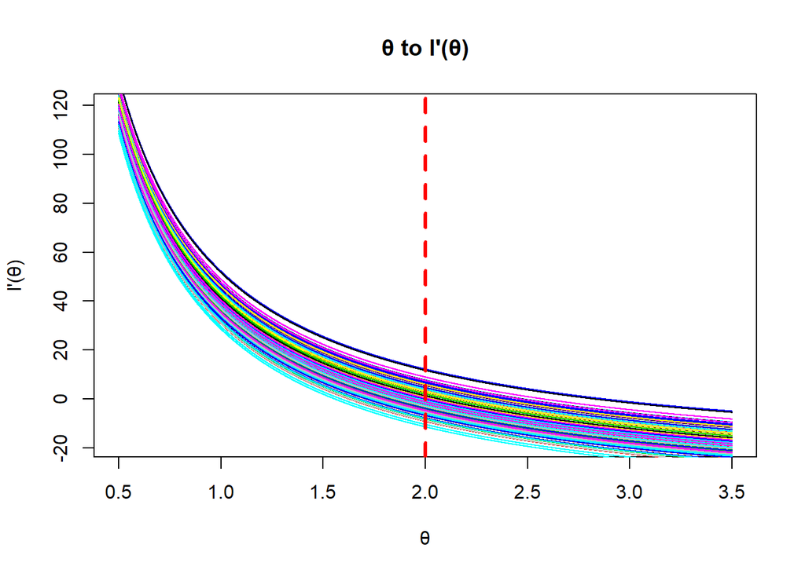

```r
lydiff<-matrix(NA,R,B)
lydiff2<-c()
for(j in 1:R){
  spl <- smooth.spline(ly[j,] ~ xx)
  for(i in 1:B){
    lydiff[j,i] <- predict(spl, x=xx[i], deriv=1)$y
  }
  if(j==1){
    plot(xx,lydiff[1,],type='l',xlab='θ',ylab = 'l\'(θ)',main='θ to l\'(θ)')
  }else{
    lines(xx,lydiff[j,],col=j)
  }
  spl2 <- smooth.spline(lydiff[j,] ~ xx)
  lydiff2[j] <- predict(spl2, x=xx[i], deriv=1)$y
}
abline(v=rate,col=2,lty=2,lwd=3)
text(rate,-180, labels=rate, col=1,cex=1.3, font=2,pos=3)
```

```r
lydiffi<-rowSums(lydiff)/B
mean(lydiffi);0
```

```
## [1] 11.89443
```

```
## [1] 0
```

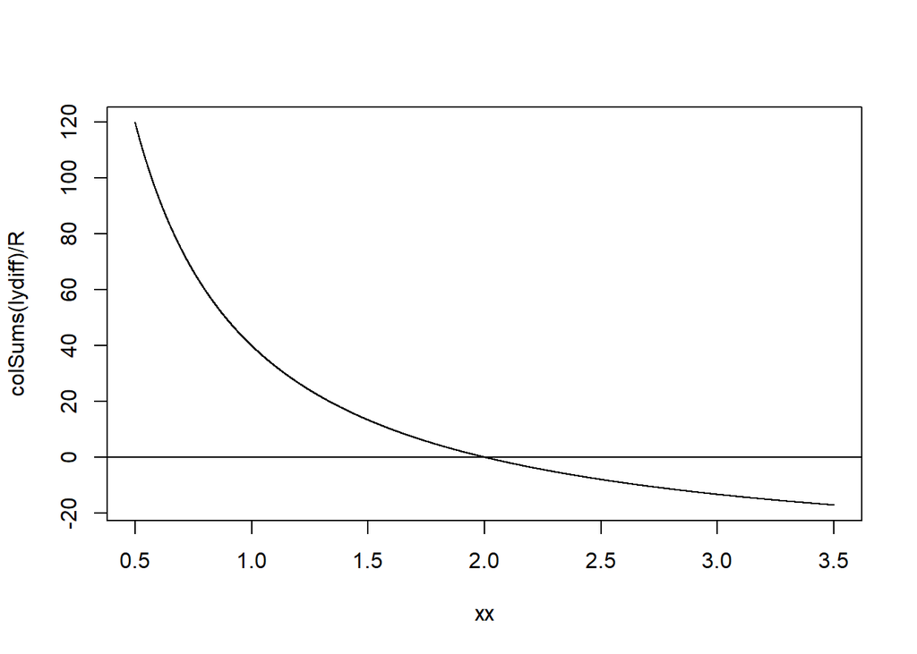

```r
plot(xx,colSums(lydiff)/R,type='l')
abline(h=0)
```

```r
spl<-spline(colSums(lydiff)/R~xx)
spl$x[which.min(abs(spl$y))]
```

```
## [1] 1.99995
```

$$I_n(\theta)=E\bigg[\bigg(\frac{\partial}{\partial \theta} logL(X;\theta)\bigg)^2\bigg]=E\bigg[\bigg(\frac{\partial }{\partial \theta}\sum^{n}_{i=1} logf(x_i;\theta)\bigg)^2\bigg]\dots\text{equation 1}
\\=
E\bigg[\sum^{n}_{i=1}\bigg(\frac{\partial }{\partial \theta} logf(x_i;\theta)\bigg)^2+\sum_{i\not=j}\frac{\partial }{\partial \theta}logf(x_i;\theta)\frac{\partial }{\partial \theta}logf(x_j;\theta)\bigg]
\\=
\sum^{n}_{i=1}E\bigg[\bigg(\frac{\partial }{\partial \theta} logf(x_i;\theta)\bigg)^2\bigg]+\sum_{i\not=j}\bigg\{E\bigg[\frac{\partial }{\partial \theta}logf(x_i;\theta)\bigg]E\bigg[\frac{\partial }{\partial \theta}logf(x_j;\theta)\bigg]\bigg\}
\\=\sum^{n}_{i=1}E\bigg[\bigg(\frac{\partial }{\partial \theta} logf(x_i;\theta)\bigg)^2\bigg]=nI_1(\theta)\dots\text{equation 2}$$

```r
In = var(lydiffi)
I1 = var(lydiffi)/n
I1
```

```
## [1] 0.2220054
```

```r
In
```

```
## [1] 17.76043
```

### 檢定

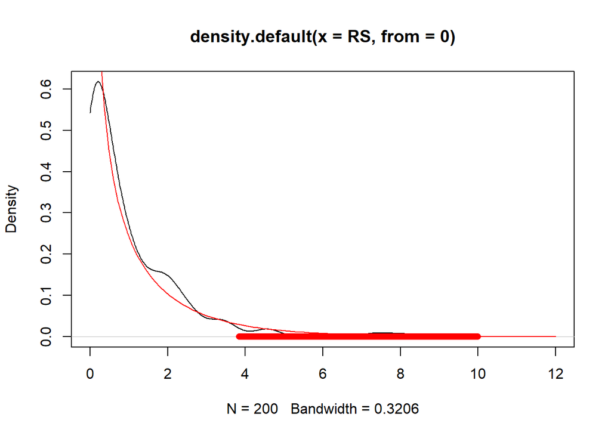

```r
lydifftheta<-c()
for(j in 1:R){
  spl <- smooth.spline(ly[j,] ~ xx)
  lydifftheta[j]<-predict(spl, x=rate,deriv=1)$y
}

U<-lydifftheta
V<-In
RS<-U^2/V
plot(density(RS,from=0),xlim=c(0,12))
curve(dchisq(x,df=1),add=T,col=2)

alpha<-0.05
#abline(h=alpha,col=2,lwd=2)
RR<-seq(qchisq(1-alpha,1),10,0.001)
points(RR,rep(0,length(RR)), col=2, pch=16, cex=1)
```

```r
mean(ifelse(RS>qchisq(1-alpha,1),1,0))  # p-value
```

```
## [1] 0.035
```

### 檢定力 Power of Test

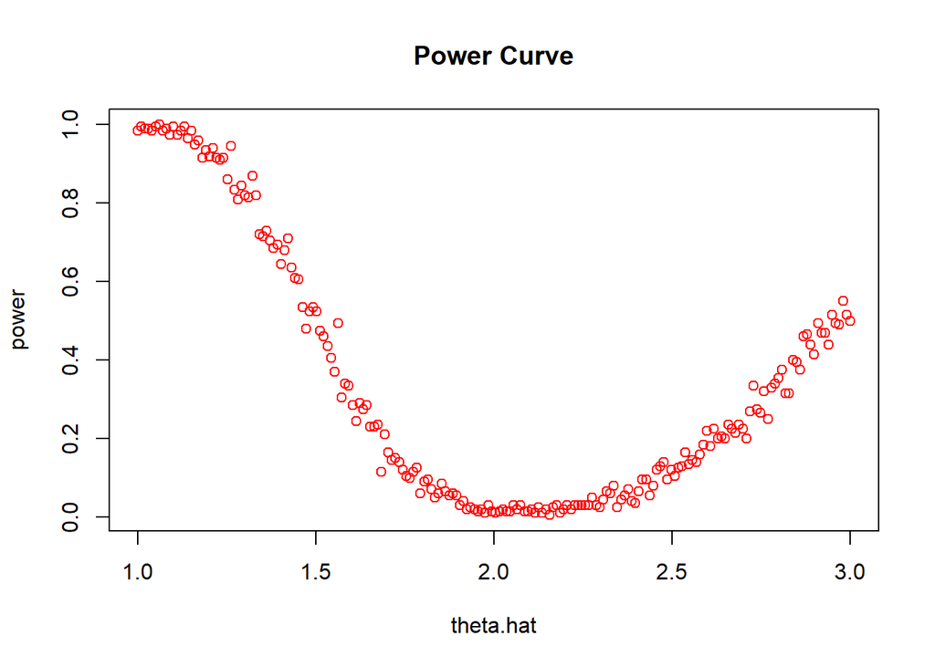

```r
B<-200
n<-50
theta0<-2
theta.hat<-seq(1, 3,length.out =B)
RS<-rep(NA,B)
power<-rep(NA,B)    #p(W>qchisq(0.95,1) | H1)
for (j in 1:B){
  H1_theta<-theta.hat[j]
  for (i in 1:B) {
    x<-rexp(n,rate=H1_theta) #Under
    V<-In
    U<-sum(1/theta0-x) # logf(x;theta) = 1/theta - x
    RS[i]<-U^2/In
  }
  power[j]<-mean(RS>qchisq(0.95,1))
}
plot(theta.hat,power,main="Power Curve",col="red")
```

### 檢定力 Power of Test

#### 在不同sample size下的power比較

$$L(\theta;x) = \prod^n_{i=1}f(x_i;\theta) = \theta^n\exp\left({-\theta}{\sum_{1}^{n}{x}_{i}} \right)$$
$$l(\theta;X)=nlog\theta-\theta\sum_{i=1}^{n}x_i$$

$$l'(\theta_0)=\frac{n}{\theta_0}-\sum_{i=1}^{n}x_i$$

$$I_1(\theta_0)=-E\bigg[\frac{\partial^2 logf(X;\theta)}{\partial \theta^2}\bigg]_{\big|\theta=\theta_0}=-E\bigg[-\frac{1}{\theta_0^2}\bigg]=\frac{1}{\theta_0^2}$$

[figure not shown]

```r
### 檢定力 Power of Test
#### 1. 在不同sample size下的power比較

B<-200
n1<-30
n2<-50
n3<-200
theta0<-2
theta.hat<-seq(1, 3, length.out =B)
RS1<-RS2<-RS3<-rep(NA,B)
power1<-power2<-power3<-rep(NA,B)    #p(W>qchisq(0.95,1) | H1)
for (j in 1:B){
  H1_mu<-theta.hat[j]
  for (i in 1:1000) {
    x1<-rexp(n1,rate=H1_mu)
    x2<-rexp(n2,rate=H1_mu)
    x3<-rexp(n3,rate=H1_mu)
    V1<-n1*I1
    V2<-n2*I1
    V3<-n3*I1
    U1<-sum(1/theta0-x1)
    U2<-sum(1/theta0-x2)
    U3<-sum(1/theta0-x3)
    RS1[i]<-U1^2/V1
    RS2[i]<-U2^2/V2
    RS3[i]<-U3^2/V3
  }
  power1[j]<-mean(RS1>qchisq(0.95,1))
  power2[j]<-mean(RS2>qchisq(0.95,1))
  power3[j]<-mean(RS3>qchisq(0.95,1))
}
plot(smooth.spline(theta.hat,power1),type="l",col=2,main="Power Curve",ylim=c(0,1),xlab=expression(theta),ylab="Power")
lines(smooth.spline(theta.hat,power2),type="l",col=3)
lines(smooth.spline(theta.hat,power3),type="l",col=4)
legend("topright",c("Simulation -- n=10","Simulation -- n=50","Simulation -- n=200"),lty = rep(1,3),col = c(2,3,4),cex = 0.8)
```

```r
score_power_rate_n1<-smooth.spline(theta.hat,power1)
score_power_rate_n2<-smooth.spline(theta.hat,power2)
score_power_rate_n3<-smooth.spline(theta.hat,power3)
```

# 比較三種test

1. 比較power的差異

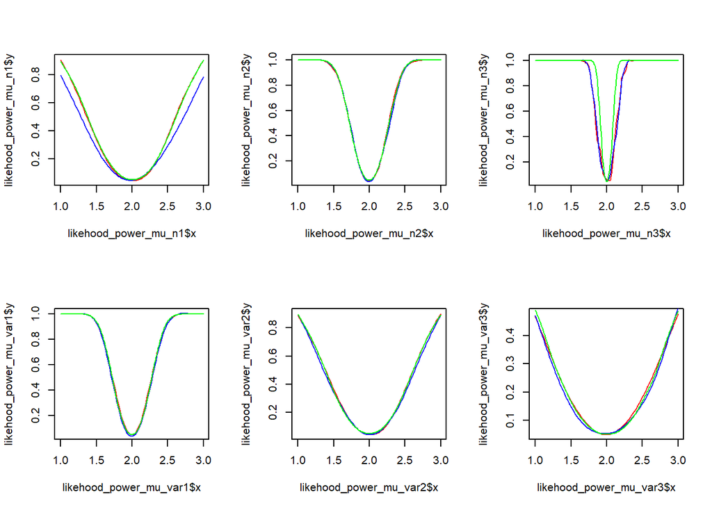

```r
par(mfrow=c(2,3))
#當N(mu,1)
plot(likehood_power_mu_n1,col="red",type='l')
lines(wald_power_mu_n1,col='blue')
lines(score_power_mu_n1,col='green')

plot(likehood_power_mu_n2,col="red",type='l')
lines(wald_power_mu_n2,col='blue')
lines(score_power_mu_n2,col='green')

plot(likehood_power_mu_n3,col="red",type='l')
lines(wald_power_mu_n3,col='blue')
lines(score_power_mu_n3,col='green')

plot(likehood_power_mu_var1,col="red",type='l')
lines(wald_power_mu_var1,col='blue')
lines(score_power_mu_var1,col='green')

plot(likehood_power_mu_var2,col="red",type='l')
lines(wald_power_mu_var2,col='blue')
lines(score_power_mu_var2,col='green')

plot(likehood_power_mu_var3,col="red",type='l')
lines(wald_power_mu_var3,col='blue')
lines(score_power_mu_var3,col='green')
```

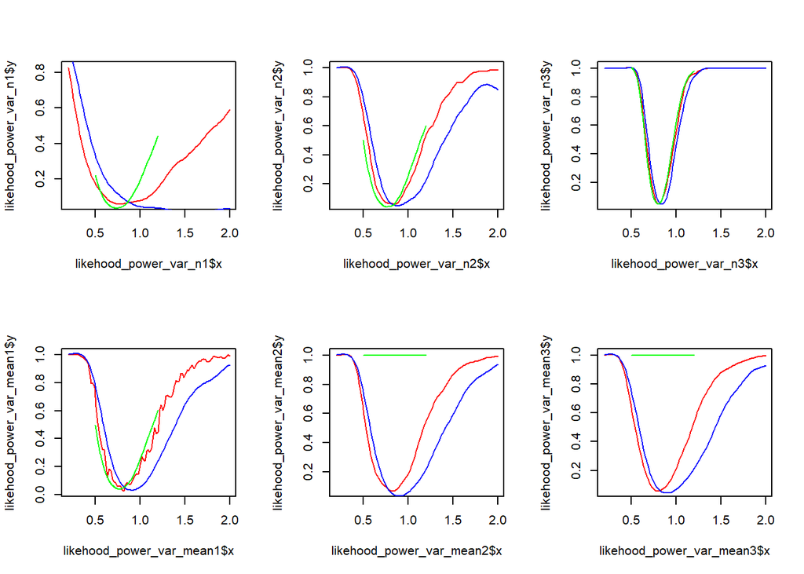

```r
par(mfrow=c(2,3))
#當N(1,theta)

plot(likehood_power_var_n1,col="red",type='l')
lines(wald_power_var_n1,col='blue')
lines(score_power_var_n1,col='green')

plot(likehood_power_var_n2,col="red",type='l')
lines(wald_power_var_n2,col='blue')
lines(score_power_var_n2,col='green')

plot(likehood_power_var_n3,col="red",type='l')
lines(wald_power_var_n3,col='blue')
lines(score_power_var_n3,col='green')

plot(likehood_power_var_mean1,col="red",type='l')
lines(wald_power_var_mean1,col='blue')
lines(score_power_var_mean1,col='green')

plot(likehood_power_var_mean2,col="red",type='l')
lines(wald_power_var_mean2,col='blue')
lines(score_power_var_mean2,col='green')


plot(likehood_power_var_mean3,col="red",type='l')
lines(wald_power_var_mean3,col='blue')
lines(score_power_var_mean3,col='green')
```

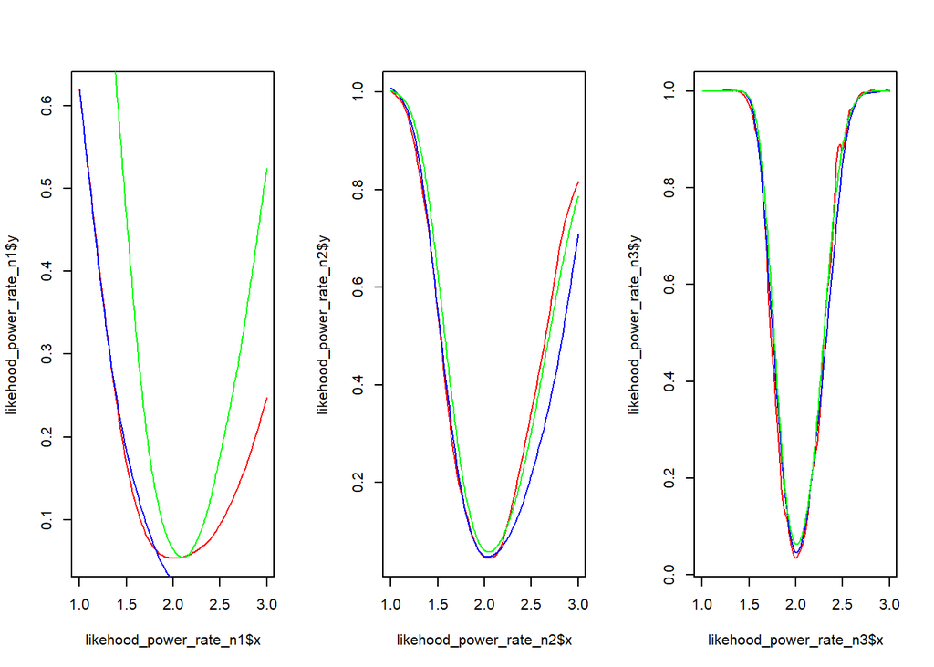

[figure not shown]

製圖：by科

```r
par(mfrow=c(1,3))
#當exp(rate)
plot(likehood_power_rate_n1,col="red",type='l')
lines(wald_power_rate_n1,col='blue')
lines(score_power_rate_n1,col='green')

plot(likehood_power_rate_n2,col="red",type='l')
lines(wald_power_rate_n2,col='blue')
lines(score_power_rate_n2,col='green')

plot(likehood_power_rate_n3,col="red",type='l')
lines(wald_power_rate_n3,col='blue')
lines(score_power_rate_n3,col='green')
```